# Reproducible Research: Peer Assessment 2

Created by Robert Tuck June 18, 2015

## Impact of Severe Weather Events on Public Health and Economy in the United States

### Synonpsis

Storms and other severe weather events can cause both public health and economic problems for communities and municipalities. Many severe events can result in fatalities, injuries, and property damage, and preventing such outcomes to the extent possible is a key concern.

This project involves exploring the U.S. National Oceanic and Atmospheric Administration’s (NOAA) storm database. This database tracks characteristics of major storms and weather events in the United States, including when and where they occur, as well as estimates of any fatalities, injuries, and property damage.

From the analysis of the data, it appears that Tornado events are the most harmful with respect to population health and Flood events have the greatest economic impact.

### Basic settings

```r
library(R.utils)
```

```r
library(ggplot2)
require(plyr)
library(car)
library(dplyr)
```

### Data Processing

```r
# download file from URL
if (!file.exists("storm.csv.bz2")) {
    download.file("https://d396qusza40orc.cloudfront.net/repdata%2Fdata%2FStormData.csv.bz2",
        "storm.csv.bz2", method = "curl")
}
# unzip file
if (!file.exists("storm.csv")) {
    bunzip2("storm.csv.bz2", "storm.csv", remove = FALSE)
}
# load data into R
storm <- read.csv("storm.csv")
head(storm)
```

```
##   STATE__           BGN_DATE BGN_TIME TIME_ZONE COUNTY COUNTYNAME STATE
## 1       1  4/18/1950 0:00:00     0130       CST     97     MOBILE    AL
## 2       1  4/18/1950 0:00:00     0145       CST      3    BALDWIN    AL
## 3       1  2/20/1951 0:00:00     1600       CST     57    FAYETTE    AL
## 4       1   6/8/1951 0:00:00     0900       CST     89    MADISON    AL
## 5       1 11/15/1951 0:00:00     1500       CST     43    CULLMAN    AL
## 6       1 11/15/1951 0:00:00     2000       CST     77 LAUDERDALE    AL
##    EVTYPE BGN_RANGE BGN_AZI BGN_LOCATI END_DATE END_TIME COUNTY_END
## 1 TORNADO         0                                               0
## 2 TORNADO         0                                               0
## 3 TORNADO         0                                               0
## 4 TORNADO         0                                               0
## 5 TORNADO         0                                               0
## 6 TORNADO         0                                               0
##   COUNTYENDN END_RANGE END_AZI END_LOCATI LENGTH WIDTH F MAG FATALITIES
```

[output cut: 20 more lines]

Get a subset of the data with columns we are interested in.

```r
### subset the data into the columns of interest
datacols <- c("EVTYPE", "FATALITIES", "INJURIES", "PROPDMG", "PROPDMGEXP", "CROPDMG", "CROPDMGEXP")
storm_data <- storm[datacols]
```

Convert the PROPDMGEXP codes into numeric values. See https://rpubs.com/flyingdisc/PROPDMGEXP for an analysis about converting these values. Then do a smilar conversion for CROPDMGEXP.

```r
# unique(storm_data$PROPDMGEXP)
# Function to recode a data column from one set a values to another
# See https://susanejohnston.wordpress.com/2012/10/01/find-and-replace-in-r-part-2-how-to-recode-many-values-simultaneously/ for additional info

recoderFunc <- function(data, oldvalue, newvalue) {
  # convert any factors to characters
  if (is.factor(data))     data     <- as.character(data)
  if (is.factor(oldvalue)) oldvalue <- as.character(oldvalue)
  if (is.factor(newvalue)) newvalue <- as.character(newvalue)

  # create the return vector
  newvec <- data

  # put recoded values into the correct position in the return vector
  for (i in unique(oldvalue)) newvec[data == i] <- newvalue[oldvalue == i]

  newvec
  }

prop_exp_from <- c("H","h","K","k","M","m","B","b","+","-","?","0","1","2","3","4","5","6","7","8","")
prop_exp_to <- c(100, 100, 1000, 1000, 1000000, 1000000, 1000000000, 100000000, 1, 0, 0, 1, 10, 100, 1000, 10000, 100000, 100000, 10000000, 100000000, 0)

storm_data$PROPEXP <- as.numeric(recoderFunc(storm_data$PROPDMGEXP, prop_exp_from, prop_exp_to))

crop_exp_from <- c("?", "K", "k", "m", "M", "B", "0", "2", "")
crop_exp_to <- c(0, 1000, 1000, 1000000, 1000000, 1000000000, 1, 100, 0)
storm_data$CROPEXP <- as.numeric(recoderFunc(storm_data$CROPDMGEXP, crop_exp_from, crop_exp_to))
```

Combine the values from PROPDMG and PROPEXP into PROPDMGVALUE by multiplying the PROPDMG by the PROPEXP to get the actual value of the proerty damage.

```r
storm_data$PROPDMGVALUE <- storm_data$PROPDMG * storm_data$PROPEXP
```

Combine the values from CROPDMG and CROPEXP into CROPDMGVALUE by multiplying the CROPDMG by the CROPEXP to get the actual value of the crop damage.

```r
storm_data$CROPDMGVALUE <- storm_data$CROPDMG * storm_data$CROPEXP
```

Add the values of the property damage (PROPDMGVALUE) and crop damage (CROPDMGVALUE) and store in a new column, TOTALDMGVALUE.

```r
storm_data$TOTALDMGVALUE <- storm_data$PROPDMGVALUE + storm_data$CROPDMGVALUE
```

Get total values of fatalities, injuries and econmic costs by aggregating values based on the type of event (EVTYPE)

```r
fatalities <- aggregate(FATALITIES ~ EVTYPE, data=storm_data, sum)
injuries <- aggregate(INJURIES ~ EVTYPE, data=storm_data, sum)
propdmg <- aggregate(PROPDMGVALUE ~ EVTYPE, data=storm_data, sum)
cropdmg <- aggregate(CROPDMGVALUE ~ EVTYPE, data=storm_data, sum)
totaldmg <- aggregate(TOTALDMGVALUE ~ EVTYPE, data=storm_data, sum)
# create a new column in the totaldmg to get costs in billions of dollars
totaldmg$VALUE_BILLION <- totaldmg$TOTALDMGVALUE / 1000000000
```

### Results

#### Across the United States, Which types of events are nost harmful with respect to population health?

```r
top10_fatalities <- head(fatalities[order(-fatalities$FATALITIES),],10)
top10_fatalities
```

```
##             EVTYPE FATALITIES
## 834        TORNADO       5633
## 130 EXCESSIVE HEAT       1903
## 153    FLASH FLOOD        978
## 275           HEAT        937
## 464      LIGHTNING        816
## 856      TSTM WIND        504
## 170          FLOOD        470
## 585    RIP CURRENT        368
## 359      HIGH WIND        248
## 19       AVALANCHE        224
```

```r
top10_injuries <- head(injuries[order(-injuries$INJURIES),], 10)
top10_injuries
```

```
##                EVTYPE INJURIES
## 834           TORNADO    91346
## 856         TSTM WIND     6957
## 170             FLOOD     6789
## 130    EXCESSIVE HEAT     6525
## 464         LIGHTNING     5230
## 275              HEAT     2100
## 427         ICE STORM     1975
## 153       FLASH FLOOD     1777
## 760 THUNDERSTORM WIND     1488
## 244              HAIL     1361
```

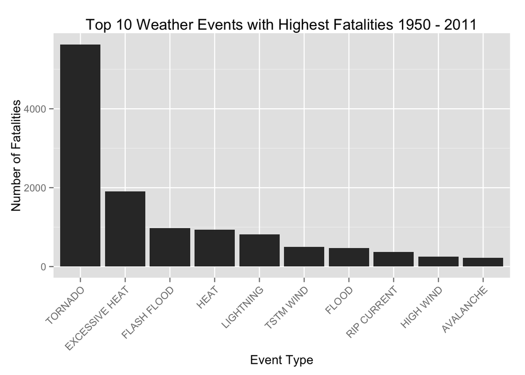

```r
ggplot(data=top10_fatalities, aes(x=reorder(EVTYPE,-FATALITIES), y=FATALITIES)) +
     geom_bar(stat="identity") +
     xlab("Event Type") +
     ylab("Number of Fatalities") +
     ggtitle("Top 10 Weather Events with Highest Fatalities 1950 - 2011") +
     theme(axis.text.x = element_text(angle = 45, hjust = 1))
```

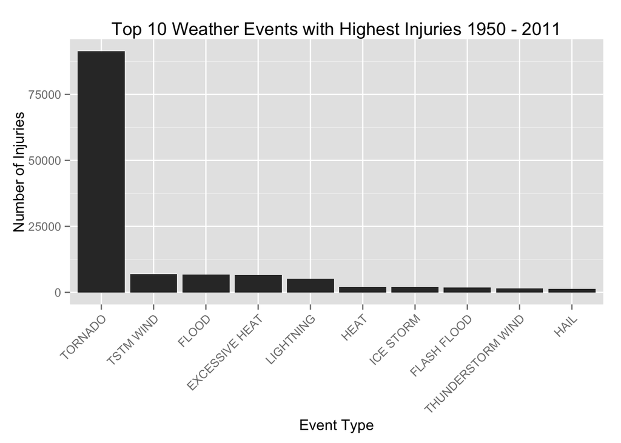

```r
ggplot(data=top10_injuries, aes(x=reorder(EVTYPE,-INJURIES), y=INJURIES)) +
     geom_bar(stat="identity") +
     xlab("Event Type") +
     ylab("Number of Injuries") +
     ggtitle("Top 10 Weather Events with Highest Injuries 1950 - 2011") +
     theme(axis.text.x = element_text(angle = 45, hjust = 1))
```

#### Across the United States, which types of events have the greatest economic consequences?

```r
top10_totaldmg <- head(totaldmg[order(-totaldmg$TOTALDMGVALUE),],10)
top10_totaldmg
```

```
##                EVTYPE TOTALDMGVALUE VALUE_BILLION
## 170             FLOOD  150319678250    150.319678
## 411 HURRICANE/TYPHOON   71913712800     71.913713
## 834           TORNADO   57362333944     57.362334
## 670       STORM SURGE   43323541000     43.323541
## 244              HAIL   18761221926     18.761222
## 153       FLASH FLOOD   18243990872     18.243991
## 95            DROUGHT   15018672000     15.018672
## 402         HURRICANE   14610229010     14.610229
## 590       RIVER FLOOD   10148404500     10.148404
## 427         ICE STORM    8967041360      8.967041
```

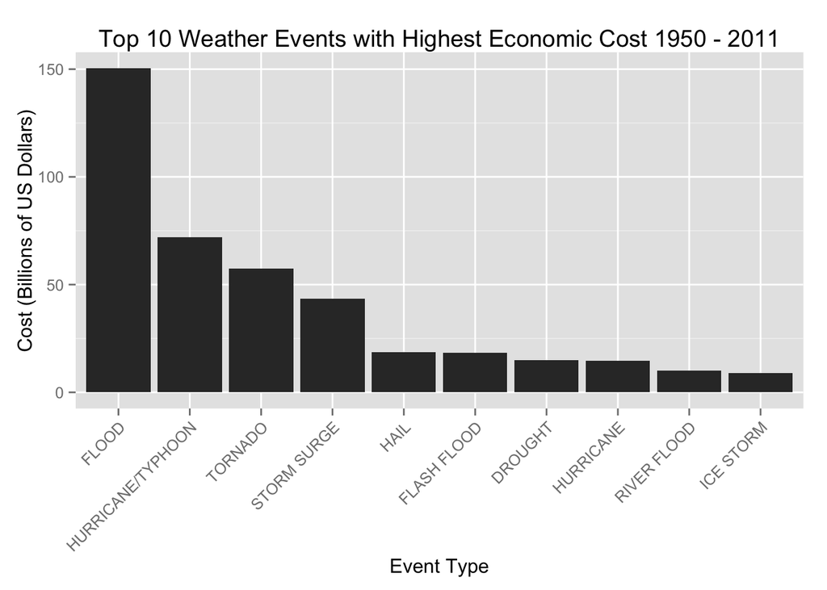

```r
ggplot(data=top10_totaldmg, aes(x=reorder(EVTYPE,-VALUE_BILLION), y=VALUE_BILLION)) +
     geom_bar(stat="identity") +
     xlab("Event Type") +
     ylab("Cost (Billions of US Dollars)") +
     ggtitle("Top 10 Weather Events with Highest Economic Cost 1950 - 2011") +
     theme(axis.text.x = element_text(angle = 45, hjust = 1))
```